# Public Crimes That Affects Other People in NYC

Jeff Tsui

February 20, 2019

Load the library

```r
library(dplyr)
library(tidyr)
library(scales)
library(plyr)
library(lubridate)
library(ggplot2)
library(GGally)
library(zoo)
```

Load the dataframe

# Analysis of Crime Complaints that happened in the Public that Violates Other People

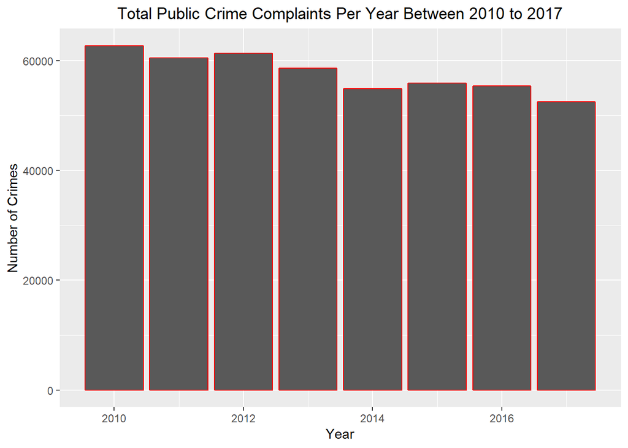

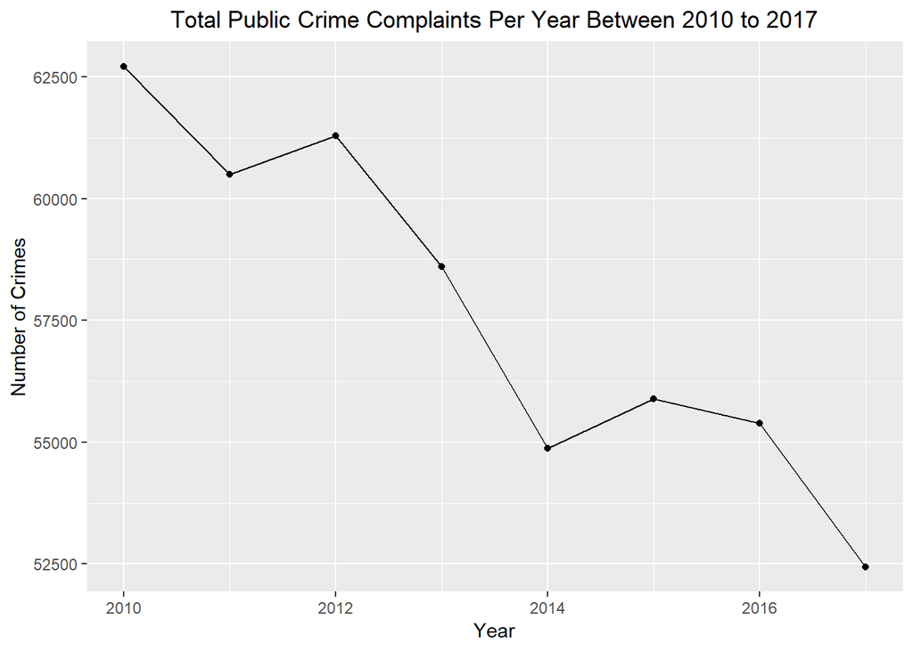

```
## [1] 62713
```

```
## [1] 52443
```

```
## [1] 0.1637619
```

The line graph below shows the changes more clearly, there is a trend of decreasing public crimes between 2010 to 2017. There is a 16.38% decrease of public crimes between 2010 to 2017.

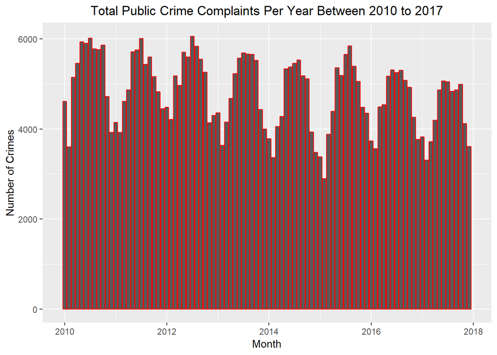

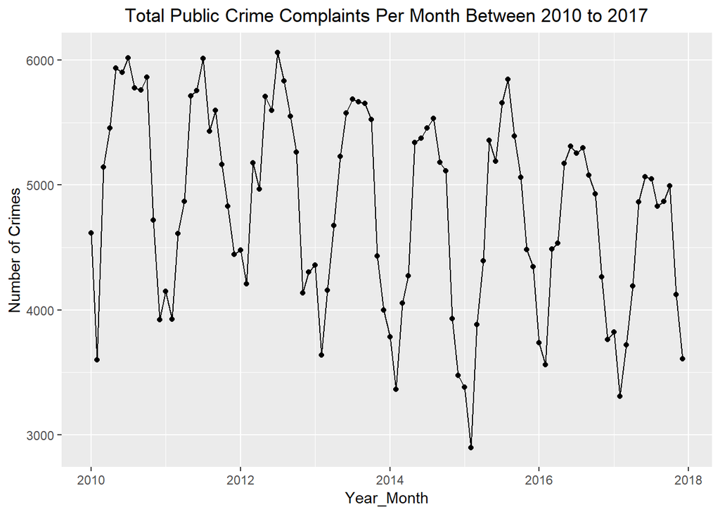

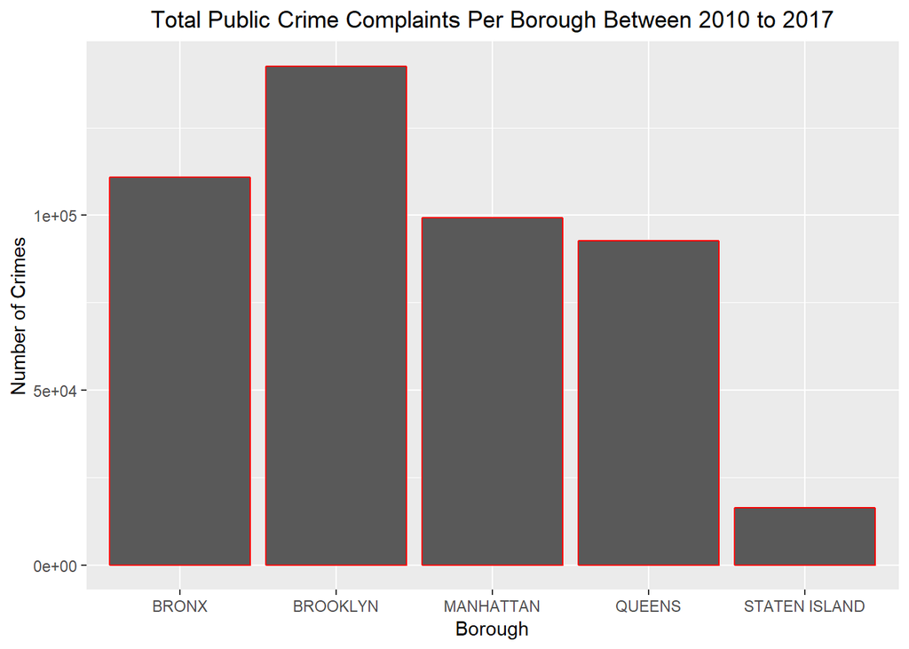

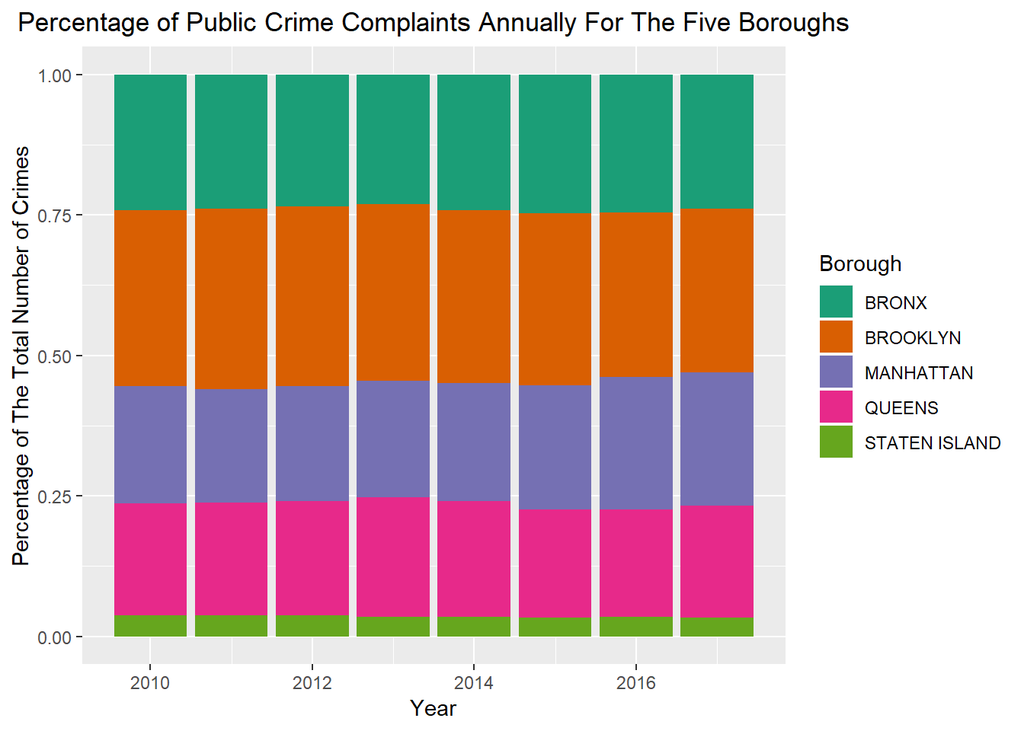

Like the percentage of public crime complaints annually for each boroughs, the monthly percentage did not show any significant changes.

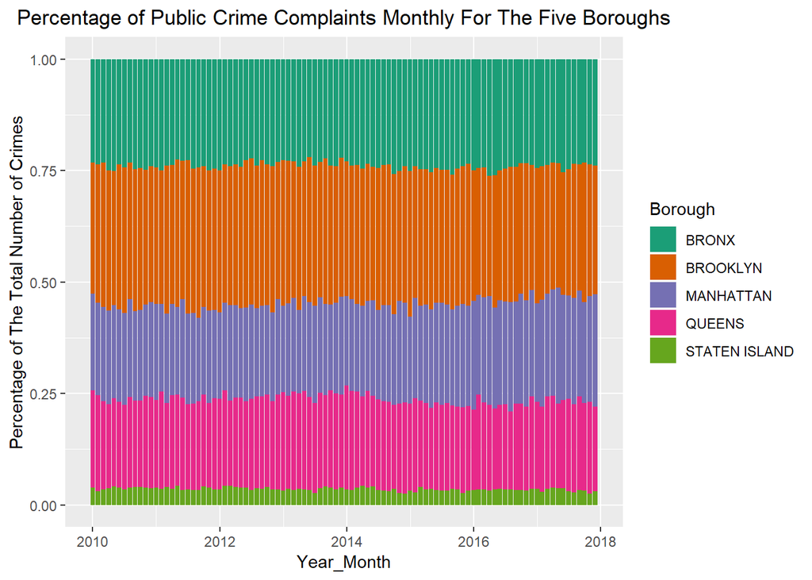

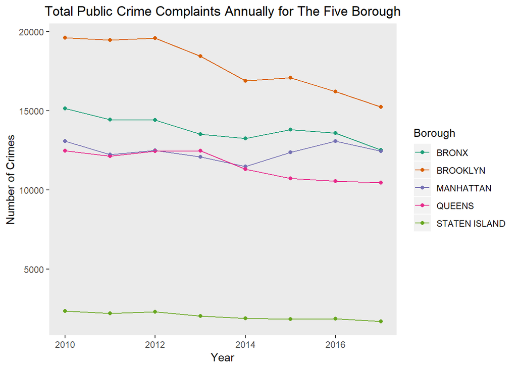

Looking at the bar graph of the total public crime complaints that happened between 2010 to 2017 for each of the five boroughs. It clearly stated that Staten Island have significantly less complaints than the other four boroughs mainly because of its population size. But Brookyln shows to have significantly more public crime complaints than other boroughs even when Queens have similar population size. Population size are determined by https://www.citypopulation.de/php/usa-newyorkcity.php. The percentage of public crime complaints annually and monthly are somewhat steady for each boroughs. From the line graph “Total Public Crime Complaints Annually for The Five Borough”, we can see that Brookyln’s public crime complaints have clearer sight of decreasing over the years. But overall the crime for each borough have decreased at the end of 2017.

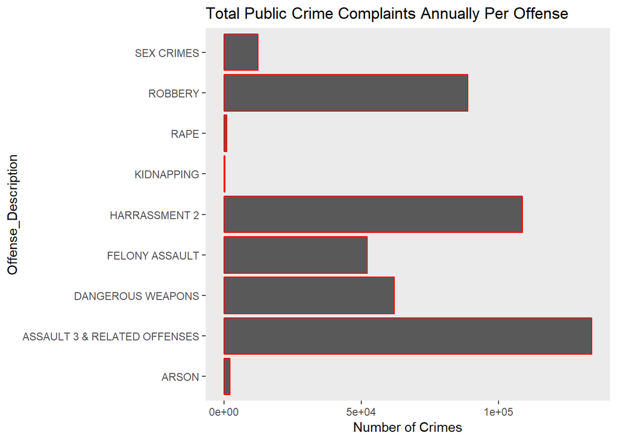

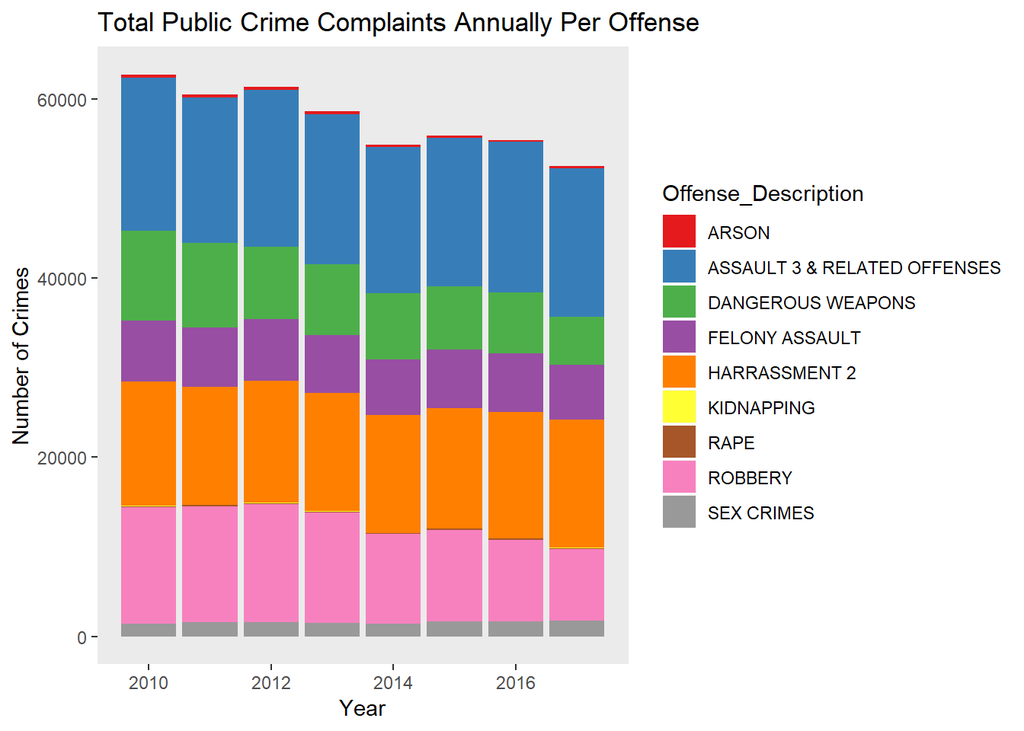

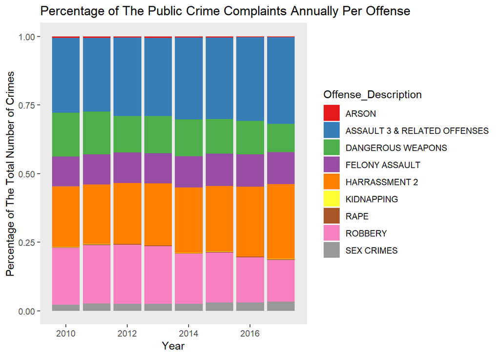

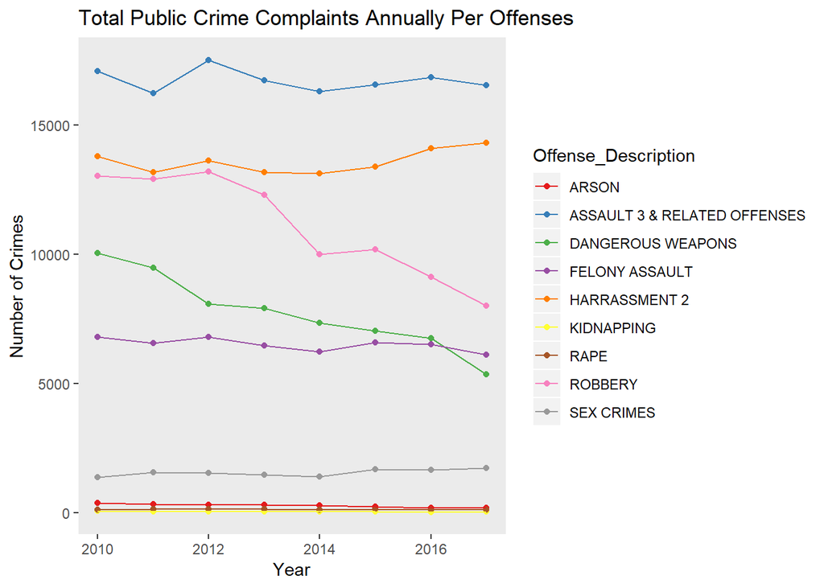

Robbery, assault level 3 & related offenses, and harrassment level 2 are the majority of the public crime complaints that is reported during 2010 to 2017 according to the bar graph “Total Public Crime Complaints Annually Per Offense.” Public crimes such as robbery and carrying dangerous weapons have shown significant decrease over the years. Harrassment level 2 have increased over the years.

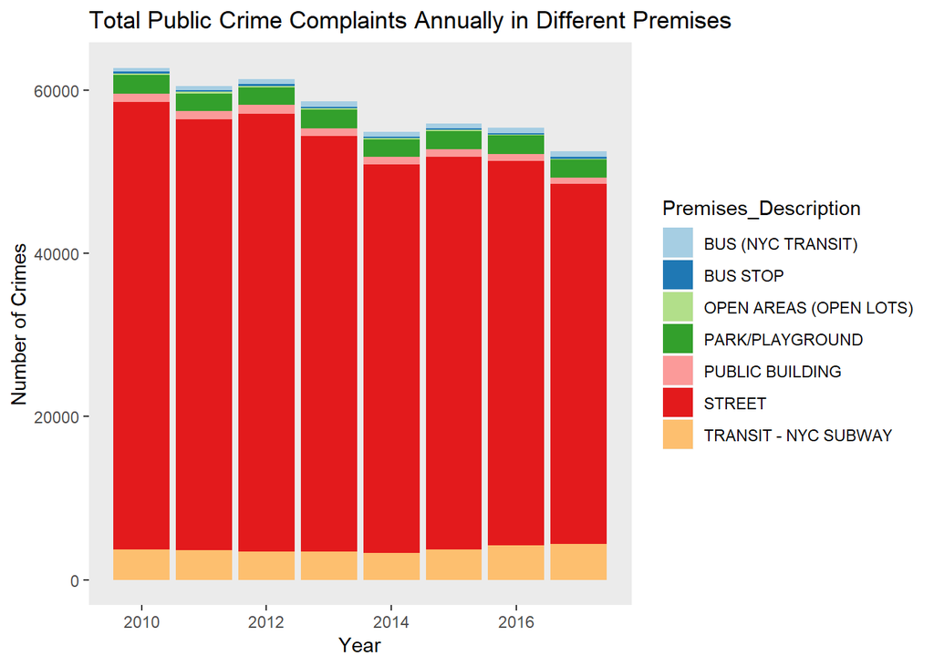

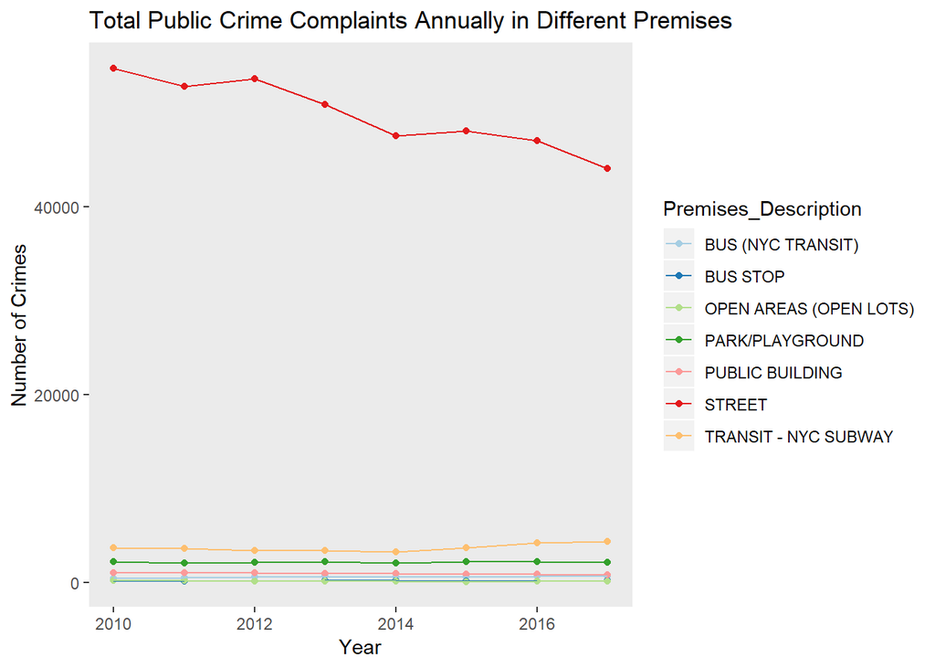

Street crime takes majority of the total public crime complaints.

# Insights, correlations and further investigations

The public crime complaints have dropped 16.38% over the years of 2010 to 2017. Crimes such as robbery and carrying dangerous weapons have shown significant decrease, while harrassment level 2 have increased sightly over the years.

Correlations" The public crime rate have dropped significantly during the winter season.

My next step could be creating a heatmap with all the latitude and longitude provided in the dataframe. And provide more correlations.